# R Notebook

```r
library(prob)
library(tidyverse)
library(janitor)
```

1. Load the data, clean_names() and explore it.

```r
mobile_phone_reviews <- read_csv("data/20190928-items.csv") %>%
  clean_names()
mobile_phone_reviews
```

| asin | brand | title | url | image | rating | review_url | total_reviews | prices |
| --- | --- | --- | --- | --- | --- | --- | --- | --- |
| B0000SX2UC | Nokia | Dual-Band / Tri-Mode Sprint PCS Phone w/ Voice Activated Dialing & Bright White Backlit Screen | https://www.amazon.com/Dual-Band-Tri-Mode-Activated-Dialing-Backlit/dp/B0000SX2UC | https://m.media-amazon.com/images/I/2143EBQ210L._AC_UY218_SEARCH213888_FMwebp_QL75_.jpg | 3.0 | https://www.amazon.com/product-reviews/B0000SX2UC | 14 | NA |
| B0009N5L7K | Motorola | Motorola I265 phone | https://www.amazon.com/Motorola-i265-I265-phone/dp/B0009N5L7K | https://m.media-amazon.com/images/I/419WBAVDARL._AC_UY218_SEARCH213888_FMwebp_QL75_.jpg | 2.9 | https://www.amazon.com/product-reviews/B0009N5L7K | 7 | $49.95 |
| B000SKTZ0S | Motorola | MOTOROLA C168i AT&T CINGULAR PREPAID GOPHONE CELL PHONE | https://www.amazon.com/MOTOROLA-C168i-CINGULAR-PREPAID-GOPHONE/dp/B000SKTZ0S | https://m.media-amazon.com/images/I/71b+q3ydkIS._AC_UY218_SEARCH213888_FMwebp_QL75_.jpg | 2.6 | https://www.amazon.com/product-reviews/B000SKTZ0S | 22 | NA |
| B00198M12M | Nokia | Nokia 6500 Slide Black/silver Unlocked Cell Phone | https://www.amazon.com/Nokia-6500-Slide-silver-Unlocked/dp/B00198M12M | https://m.media-amazon.com/images/I/41ss4HpLkLL._AC_UY218_SEARCH213888_FMwebp_QL75_.jpg | 2.4 | https://www.amazon.com/product-reviews/B00198M12M | 5 | NA |
| B001AO4OUC | Motorola | Motorola i335 Cell Phone Boost Mobile | https://www.amazon.com/Motorola-i335-Phone-Boost-Mobile/dp/B001AO4OUC | https://m.media-amazon.com/images/I/710UO8gdT+L._AC_UY218_SEARCH213888_FMwebp_QL75_.jpg | 3.3 | https://www.amazon.com/product-reviews/B001AO4OUC | 21 | NA |
| B001DCJAJG | Motorola | Motorola V365 no contract cellular phone AT&T | https://www.amazon.com/Motorola-V365-contract-cellular-phone/dp/B001DCJAJG | https://m.media-amazon.com/images/I/61LYNCVrrKL._AC_UY218_SEARCH213888_FMwebp_QL75_.jpg | 3.2 | https://www.amazon.com/product-reviews/B001DCJAJG | 12 | NA |
| B001DZY4KI | Sony | Sony Ericsson G700 Triband GSM Phone Bronze (Unlocked) | https://www.amazon.com/Sony-Ericsson-Triband-Bronze-Unlocked/dp/B001DZY4KI | https://m.media-amazon.com/images/I/51mL10InzcL._AC_UY218_SEARCH213888_FMwebp_QL75_.jpg | 2.0 | https://www.amazon.com/product-reviews/B001DZY4KI | 1 | $78.99 |
| B001GQ3DJM | Nokia | Nokia 1680 Black Phone (T-Mobile) | https://www.amazon.com/Nokia-1680-Black-Phone-T-Mobile/dp/B001GQ3DJM | https://m.media-amazon.com/images/I/41X4VeqkFOL._AC_UY218_SEARCH213888_FMwebp_QL75_.jpg | 2.7 | https://www.amazon.com/product-reviews/B001GQ3DJM | 3 | NA |
| B0027VKQPE | Nokia | Nokia New 1100 for Tracfone | https://www.amazon.com/New-Nokia-1100-for-Tracfone/dp/B0027VKQPE | https://m.media-amazon.com/images/I/91IUe3nDP7L._AC_UY218_SEARCH213888_FMwebp_QL75_.jpg | 3.2 | https://www.amazon.com/product-reviews/B0027VKQPE | 8 | $99.99 |
| B00280QJFU | Samsung | Samsung T301G Prepaid Phone (Tracfone) | https://www.amazon.com/Samsung-T301G-Prepaid-Phone-Tracfone/dp/B00280QJFU | https://m.media-amazon.com/images/I/71QX+Kiri4L._AC_UY218_SEARCH213888_FMwebp_QL75_.jpg | 3.5 | https://www.amazon.com/product-reviews/B00280QJFU | 133 | $59.89 |

[output cut: 782 more lines]

```r
glimpse(mobile_phone_reviews)
```

```
Rows: 792
Columns: 9
$ asin          <chr> "B0000SX2UC", "B0009N5L7K", "B000SKTZ0S", "B00198M12M", "B001AO4OUC", "B001DCJAJG", "B001DZY4KI", "B…
$ brand         <chr> "Nokia", "Motorola", "Motorola", "Nokia", "Motorola", "Motorola", "Sony", "Nokia", "Nokia", "Samsung…
$ title         <chr> "Dual-Band / Tri-Mode Sprint PCS Phone w/ Voice Activated Dialing & Bright White Backlit Screen", "M…
$ url           <chr> "https://www.amazon.com/Dual-Band-Tri-Mode-Activated-Dialing-Backlit/dp/B0000SX2UC", "https://www.am…
$ image         <chr> "https://m.media-amazon.com/images/I/2143EBQ210L._AC_UY218_SEARCH213888_FMwebp_QL75_.jpg", "https://…
$ rating        <dbl> 3.0, 2.9, 2.6, 2.4, 3.3, 3.2, 2.0, 2.7, 3.2, 3.5, 2.9, 2.9, 2.8, 2.8, 2.6, 3.2, 2.9, 2.0, 3.4, 3.5, …
$ review_url    <chr> "https://www.amazon.com/product-reviews/B0000SX2UC", "https://www.amazon.com/product-reviews/B0009N5…
$ total_reviews <dbl> 14, 7, 22, 5, 21, 12, 1, 3, 8, 133, 2, 18, 201, 76, 131, 66, 3, 15, 102, 146, 348, 56, 73, 23, 8, 19…
$ prices        <chr> NA, "$49.95", NA, NA, NA, NA, "$78.99", NA, "$99.99", "$59.89", "$99.95", "$149.95", NA, NA, NA, NA,…
```

```r
#unique(mobile_phone_reviews$asin)
```

2. Find the brand with the highest numbers of phones in the dataset.

```r
mobile_phone_reviews %>%
  group_by(brand) %>%
  summarise(count = n()) %>%
  arrange(desc(count)) %>%
  head(1)
```

| brand | count |
| --- | --- |
| Samsung | 397 |

```r
NA
```

Ans: Top brand is Samsung with highest number of phones!

3. For your top brand, plot the distribution of phone ratings as a probability density, overlaying a fitted normal distribution. Do you think the normal distribution provides a good model of these ratings?

```r
top_brand_stats <- mobile_phone_reviews %>%
  filter(brand == "Samsung") %>% #we know that top brand is Samsung
  summarise(
    num = n(),
    mean = mean(rating),
    sd = sd(rating)
  )
top_brand_stats
```

| num | mean | sd |
| --- | --- | --- |
| 397 | 3.5733 | 0.6847859 |

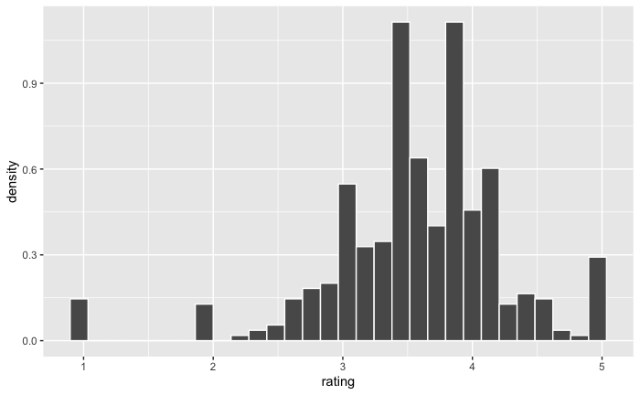

```r
mobile_phone_reviews %>%
  filter(brand == "Samsung") %>%
  ggplot() +
  aes(x = rating, y = ..density..) +
  geom_histogram(bins = 30, col = "white")
```

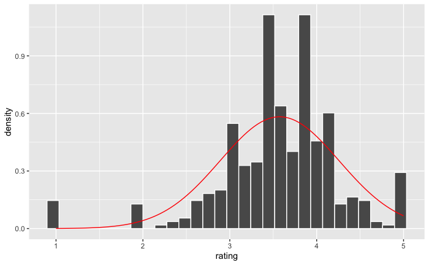

```r
mobile_phone_reviews %>%
  filter(brand == "Samsung") %>%
  ggplot() +
  aes(x = rating) +
  geom_histogram(aes(y = ..density..), bins = 30, col = "white") +
  stat_function(
    fun = dnorm,
    args = list(
      mean = top_brand_stats$mean,
      sd = top_brand_stats$sd
    ),
    col = "red"
  )
```

```r
NA
NA
```

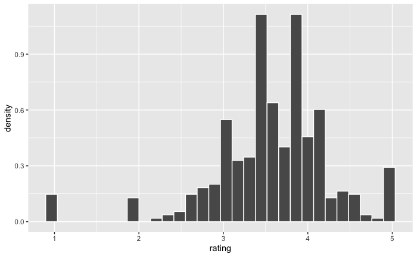

```r
library(MASS)
mobile_phone_reviews %>%
  filter(brand == "Samsung") %>%
  ggplot() +
  aes(x = rating) +
  geom_histogram(aes(y = ..density..), bins = 30, col = "white")
```

```r
fitdistr(mobile_phone_reviews$rating, "normal")
```

```
      mean          sd
  3.60757576   0.66830721
 (0.02374726) (0.01679185)
```

4. We can be more quantitative in comparing the distribution of top brand ratings with a normal distribution. You calculated the mean() and sd() of your distribution in an earlier question. Use these values to calculate the proportions of ratings within one-, two- and three standard deviations of the mean. Compare these proportions with those you expect for a normal distribution.

```r
mobile_phone_reviews %>%
  filter(rating >= top_brand_stats$mean - top_brand_stats$sd) %>%
  filter(rating <= top_brand_stats$mean + top_brand_stats$sd) %>%
  summarise(prop_within_1sd = n() / nrow(mobile_phone_reviews))
```

| prop_within_1sd |
| --- |
| 0.7815657 |

```r
mobile_phone_reviews %>%
  filter(rating >= top_brand_stats$mean - 2*top_brand_stats$sd) %>%
  filter(rating <= top_brand_stats$mean + 2*top_brand_stats$sd) %>%
  summarise(prop_within_2sd = n() / nrow(mobile_phone_reviews))
```

| prop_within_2sd |
| --- |
| 0.9330808 |

```r
mobile_phone_reviews %>%
  filter(rating >= top_brand_stats$mean - 3*top_brand_stats$sd) %>%
  filter(rating <= top_brand_stats$mean + 3*top_brand_stats$sd) %>%
  summarise(prop_within_3sd = n() / nrow(mobile_phone_reviews))
```

| prop_within_3sd |
| --- |
| 0.9848485 |

```r
# The percentage of values within 1, 2 & 3 standard deviations of the mean
(pnorm(q = 1) - pnorm(q = -1))
```

```
[1] 0.6826895
```

```r
(pnorm(q = 2) - pnorm(q = -2))
```

```
[1] 0.9544997
```

```r
(pnorm(q = 3) - pnorm(q = -3))
```

```
[1] 0.9973002
```

Normal: 0.9330808  
Standard Normal: 0.9544997

Normal: 0.9848485  
Standard normal: 0.9973002

X X X X X X X X X X X X X X X X X X X X X X X X X X X X X X X X X X X X X

Extension

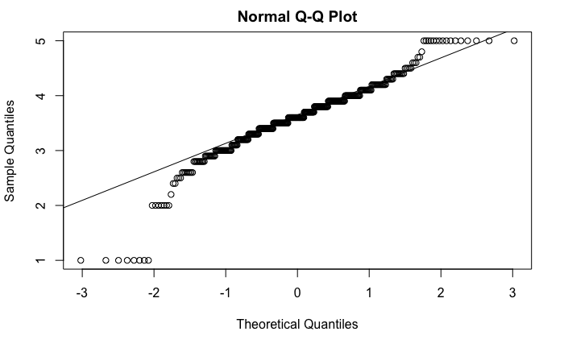

```r
test <- mobile_phone_reviews %>%
  filter(brand == "Samsung")
#test
qqnorm(test$rating)
qqline(test$rating)
```

Ans: qq plot take the sample data (rating), sorts it in an ascending order and then plot it versus quantiles calculated from a theoretical distribution. The number of quantiles is selected to match the size of the sample data.

qqnorm creates a normal Q-Q plot.

```r
samsung_ratings <- mobile_phone_reviews %>%
  filter(brand == "Samsung") %>%
  dplyr::select(rating)
```